# Prediction Assignment Writeup

Ardeshir Damavandi

September 20, 2014

## Load Data and Packages

In this section, I simply load the csv files into R objects from my working directory.

```r
library(caret)
library(corrplot)
```

```r
pmlTrain <- read.csv("pml-training.csv")
pmlTest <- read.csv("pml-testing.csv")
```

The dimensions for *pmlTrain* and *pmlTest* are respectively:

```
## [1] 19622   160
```

```
## [1]  20 160
```

## Clean Data

First I replace every error code (#DIV/0!), blank cells and NA values by “NA”. Then I keep the columns which have no NA value. Also I have removed the first 7 columns, because they are not considered to be predictors for Classe variable.

```r
# Data Cleaning -----------------------------------------------------------

# Train Data
pmlTrain[pmlTrain=="" | pmlTrain=="#DIV/0!"] <- NA
pmlTrain <- pmlTrain[, colSums(is.na(pmlTrain))==0]
pmlTrain <- pmlTrain[,-c(1:7)]

# Test Data
pmlTest[pmlTest=="" | pmlTest=="#DIV/0!"] <- NA
pmlTest <- pmlTest[, colSums(is.na(pmlTest))==0]
pmlTest <- pmlTest[,-c(1:7)]
```

After removing the missing data, the dimensions for *pmlTrain* and *pmlTest* are respectively:

```
## [1] 19622    53
```

```
## [1] 20 53
```

## Partitioning The Data

In order to have best performance in Accuracy and minimizing the Out Sample Error, I split the Training Data into 60% for training purpose and 40% for cross validation.

```r
# Bootstrap ----------------------------------------------------------------

set.seed(21)
inTrain <- createDataPartition(pmlTrain$classe, p = 0.6, list = F)
training <- pmlTrain[inTrain,]
testing <- pmlTrain[-inTrain,]
```

Now, the dimensions for *training* and *testing* are respectively:

```
## [1] 11776    53
```

```
## [1] 7846   53
```

## Exploratory Data Analysis

I started with the frequencies of the Classe which we have to predict. In this way, we may have more ideas in building models for better Specificity and Sensitivity Values. Correlation between predictors is also an important issue. Thus, I tried to find the high correlated features and omit them in my model.

```r
# Explore Training Data ---------------------------------------------------

# Correlations
correlationMatrix <- cor(subset(training, select=-c(classe)))
highlyCorrelated <- findCorrelation(correlationMatrix, .90)
```

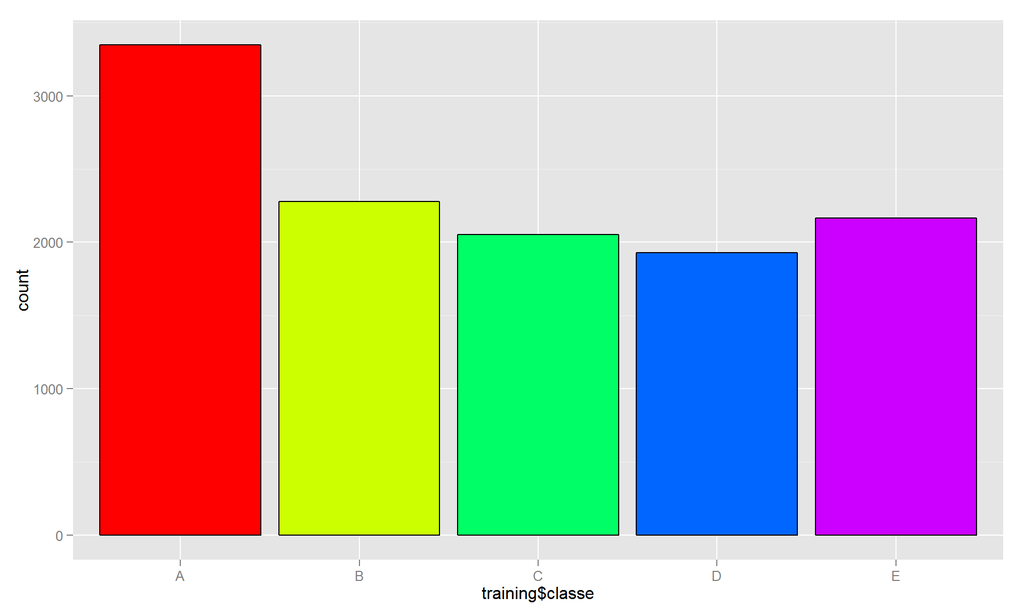

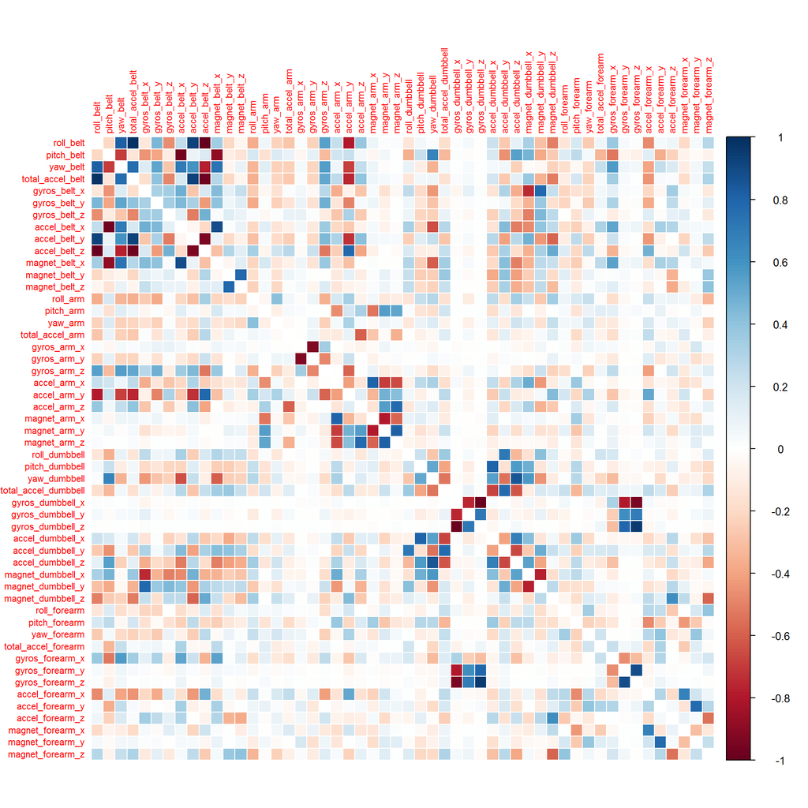

The highly correlated features are:

```
## [1] "accel_belt_z"     "roll_belt"        "accel_belt_y"
## [4] "accel_belt_x"     "gyros_arm_y"      "gyros_forearm_z"
## [7] "gyros_dumbbell_x"
```

```r
# Remove highly correlated Features
training <- training[, -highlyCorrelated]
```

## Building Model

Since this is a Classification problem and has different predictors with non-linear behavior, I decided to train my data using Random Forest and Gradiant Boosting Machine. In building both models, I used 4-fold cross validation.

```r
# Models ------------------------------------------------------------------

# General Train Parameters
modelControl <- trainControl(method = "cv",
                         number = 4)
```

In addition, I tried to find best `mtry` value in Random Forest by setting this parameter with different values.

```r
# Random Forest
model_rf <- train(classe ~ ., data = training,
               method = "rf", ntree=50,
               importance=T,
               trControl = modelControl,
               tuneGrid = data.frame(mtry = c(3,10,23,35,46)))
```

```
## Random Forest
##
## 11776 samples
##    45 predictors
##     5 classes: 'A', 'B', 'C', 'D', 'E'
##
## No pre-processing
## Resampling: Cross-Validated (4 fold)
##
## Summary of sample sizes: 8832, 8831, 8832, 8833
##
## Resampling results across tuning parameters:
##
##   mtry  Accuracy  Kappa  Accuracy SD  Kappa SD
##   3     1         1      0.002        0.003
##   10    1         1      0.002        0.002
##   20    1         1      0.003        0.003
##   40    1         1      0.001        0.002
##   50    1         1      0.003        0.003
##
## Accuracy was used to select the optimal model using  the largest value.
## The final value used for the model was mtry = 23.
```

To choose the best `mtry` and show the importance level of top 10 features, we have:

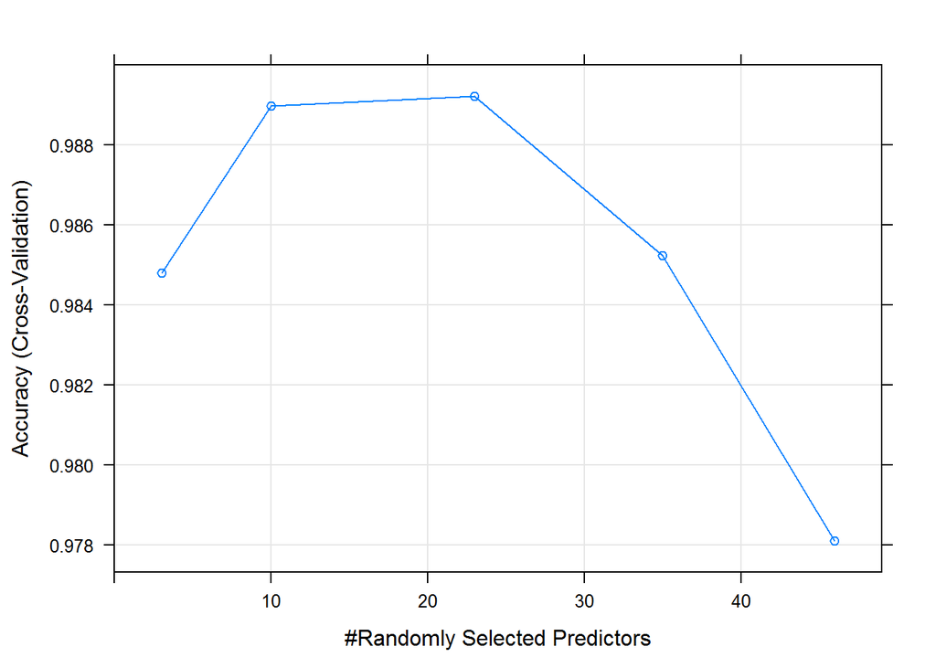

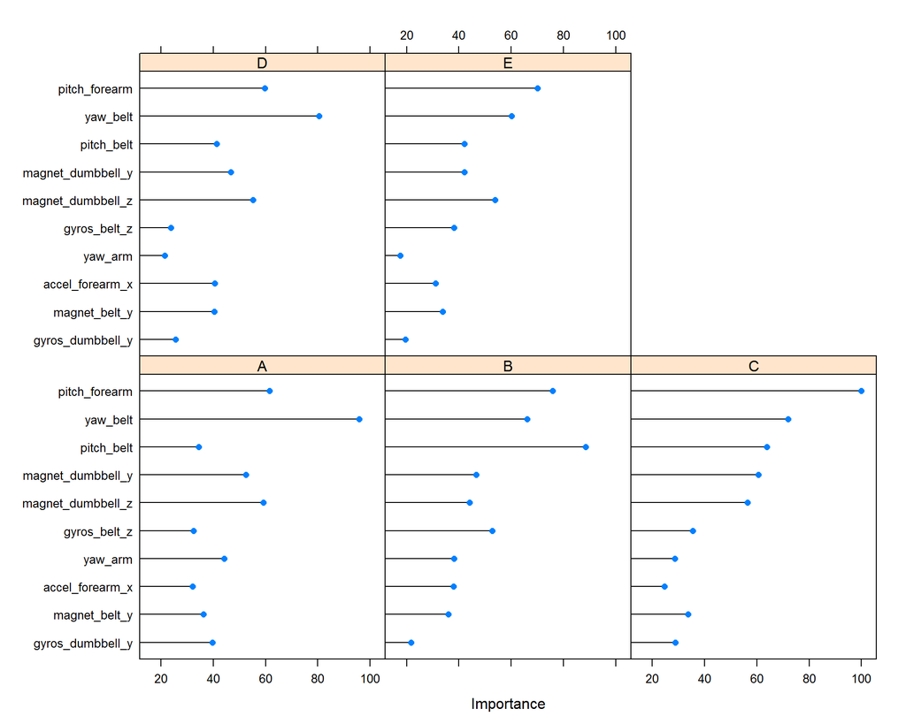

Now for GBM Model, I tried 3 different values of `interaction.depth` with the following parameters.

```r
# GBM
gbmControl <- expand.grid(n.trees=c(10,30,50),
                          interaction.depth=c(1,3,6),
                          shrinkage= 0.1)
model_gbm <- train(classe ~ ., data = training,
                  method = "gbm", tuneGrid=gbmControl,
                  trControl = modelControl)
```

```
## Stochastic Gradient Boosting
##
## 11776 samples
##    45 predictors
##     5 classes: 'A', 'B', 'C', 'D', 'E'
##
## No pre-processing
## Resampling: Cross-Validated (4 fold)
##
## Summary of sample sizes: 8831, 8831, 8833, 8833
##
## Resampling results across tuning parameters:
##
##   interaction.depth  n.trees  Accuracy  Kappa  Accuracy SD  Kappa SD
##   1                  10       0.6       0.5    0.02         0.02
##   1                  30       0.7       0.6    0.02         0.02
##   1                  50       0.7       0.7    0.008        0.01
##   3                  10       0.7       0.6    0.007        0.009
##   3                  30       0.8       0.8    0.007        0.009
##   3                  50       0.9       0.9    0.007        0.009
##   6                  10       0.8       0.8    0.009        0.01
##   6                  30       0.9       0.9    0.006        0.007
##   6                  50       0.9       0.9    0.006        0.007
##
## Tuning parameter 'shrinkage' was held constant at a value of 0.1
## Accuracy was used to select the optimal model using  the largest value.
## The final values used for the model were n.trees = 50, interaction.depth
##  = 6 and shrinkage = 0.1.
```

Below plot shows the relationship between the estimates of performance and the tuning parameters.

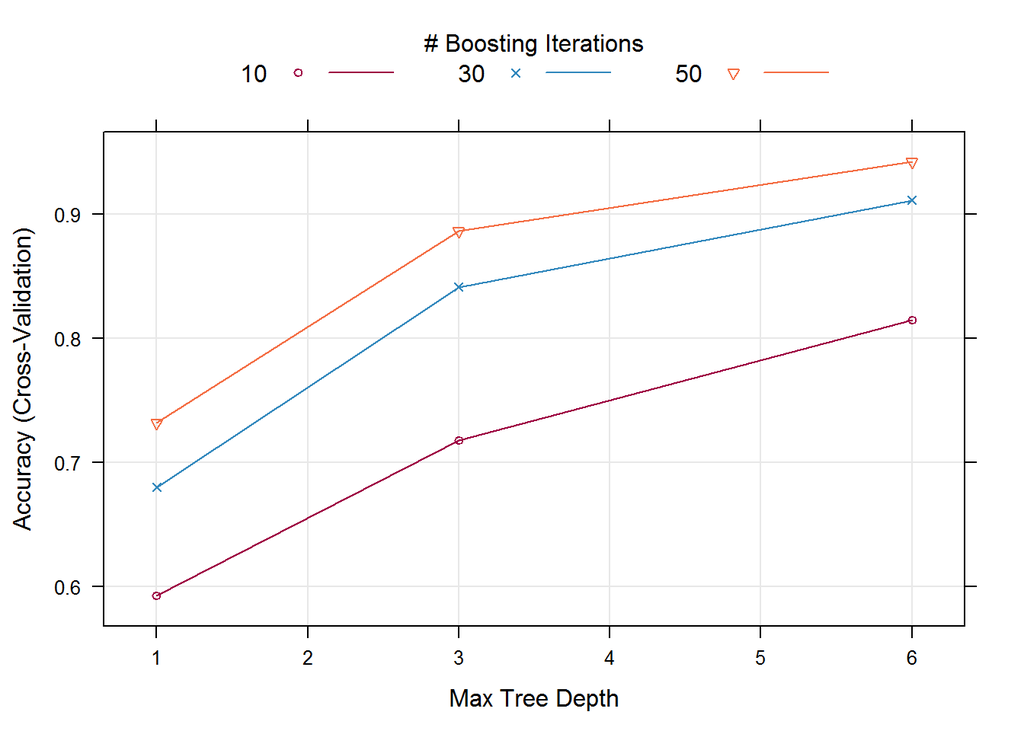

As a result, the `mtry=23` for the Random Forest Model and the `interaction.depth=6` for the GBM Model are better choices.

## Out Sample Error

Then I used each model to predict the Testing data (40% of total Data) and calculate the our sample error.

```r
# Out Sample Error --------------------------------------------------------

# Model Fit, Random Forest
prediction_rf <- predict(model_rf, testing)

# Model Fit, GBM
prediction_gbm <- predict(model_gbm, testing)

# Confusion Matrix and Statistics
confusion_rf <- confusionMatrix(prediction_rf, testing$classe)
confusion_gbm <- confusionMatrix(prediction_gbm, testing$classe)
```

Now we can compare the two models accuracy on the Test Data.

Confusion Matrix for Random Forest Model:

```
## Confusion Matrix and Statistics
##
##           Reference
## Prediction    A    B    C    D    E
##          A 2227   22    0    0    0
##          B    2 1486   13    0    0
##          C    1   10 1349   12    0
##          D    2    0    4 1272    1
##          E    0    0    2    2 1441
##
## Overall Statistics
##
##                Accuracy : 0.991
##                  95% CI : (0.989, 0.993)
##     No Information Rate : 0.284
##     P-Value [Acc > NIR] : <2e-16
##
##                   Kappa : 0.989
##  Mcnemar's Test P-Value : NA
##
## Statistics by Class:
##
##                      Class: A Class: B Class: C Class: D Class: E
## Sensitivity             0.998    0.979    0.986    0.989    0.999
## Specificity             0.996    0.998    0.996    0.999    0.999
## Pos Pred Value          0.990    0.990    0.983    0.995    0.997
## Neg Pred Value          0.999    0.995    0.997    0.998    1.000
## Prevalence              0.284    0.193    0.174    0.164    0.184
## Detection Rate          0.284    0.189    0.172    0.162    0.184
## Detection Prevalence    0.287    0.191    0.175    0.163    0.184
## Balanced Accuracy       0.997    0.988    0.991    0.994    0.999
```

Confusion Matrix for GBM Model:

```
## Confusion Matrix and Statistics
##
##           Reference
## Prediction    A    B    C    D    E
##          A 2191   95    1    2    8
##          B   20 1366   57    2   21
##          C    5   45 1293   50   24
##          D   15    4    9 1208   12
##          E    1    8    8   24 1377
##
## Overall Statistics
##
##                Accuracy : 0.948
##                  95% CI : (0.942, 0.952)
##     No Information Rate : 0.284
##     P-Value [Acc > NIR] : <2e-16
##
##                   Kappa : 0.934
##  Mcnemar's Test P-Value : <2e-16
##
## Statistics by Class:
##
##                      Class: A Class: B Class: C Class: D Class: E
## Sensitivity             0.982    0.900    0.945    0.939    0.955
## Specificity             0.981    0.984    0.981    0.994    0.994
## Pos Pred Value          0.954    0.932    0.912    0.968    0.971
## Neg Pred Value          0.993    0.976    0.988    0.988    0.990
## Prevalence              0.284    0.193    0.174    0.164    0.184
## Detection Rate          0.279    0.174    0.165    0.154    0.176
## Detection Prevalence    0.293    0.187    0.181    0.159    0.181
## Balanced Accuracy       0.981    0.942    0.963    0.967    0.974
```

## Submission

Because of the higher out sample Accuracy, I choose the Random Forest Model to predict the assignment test data. Finally, I get *20/20* from the assignment.

```r
# Submission ---------------------------------------------------------------

answers <- predict(model_rf, pmlTest)

pml_write_files = function(x){
  n = length(x)
  for(i in 1:n){
    filename = paste0("problem_id_",i,".txt")
    write.table(x[i],file=filename,quote=FALSE,row.names=FALSE,col.names=FALSE)
  }
}

pml_write_files(answers)
```